# Final Exam -Data 606

N. Nedd

2017-05-25

## Part I

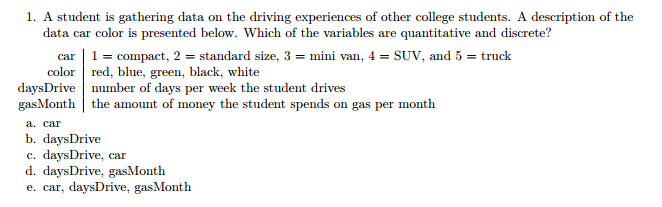

**Ans: b. daysDrive**

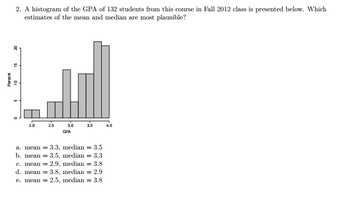

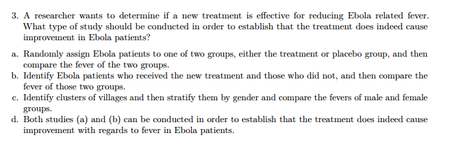

**Ans: a. Randomly assign Ebola patients to one of two groups, either the treatment or placebo group, and then compare the fever of the two groups**

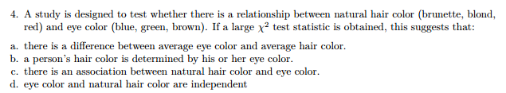

**Ans: c. there is an association between natural hair colour and eye colour**

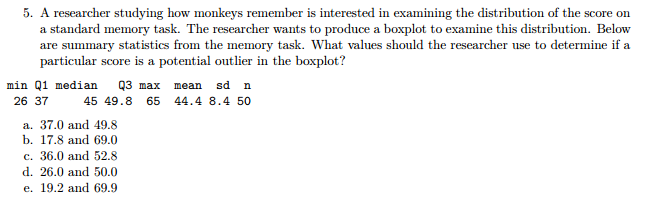

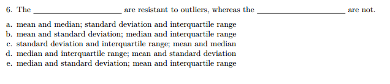

**Ans: median and interquartile range; mean and standard deviation**

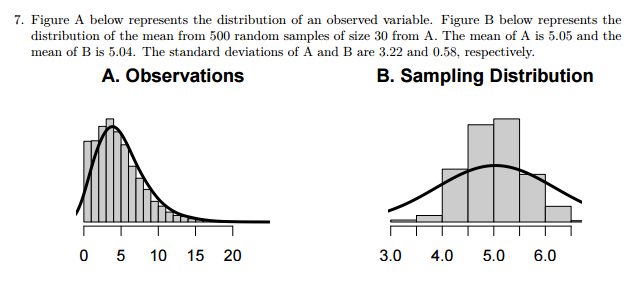

**Ans: Distrbution A is postively skewed and Distribution B is close to normally distributed**

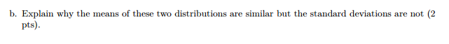

**Ans: Both distributions show curves that peak at around 5 since distribution B is a sample of distribution A. Distribution B however has less spread since it involves less values when compared to Distribution A.**

**Ans: The Central Limit Theorem says that when a sample is taken from a population the larger it gets(around 30) the more normal the sample distribution becomes.**

## Part II

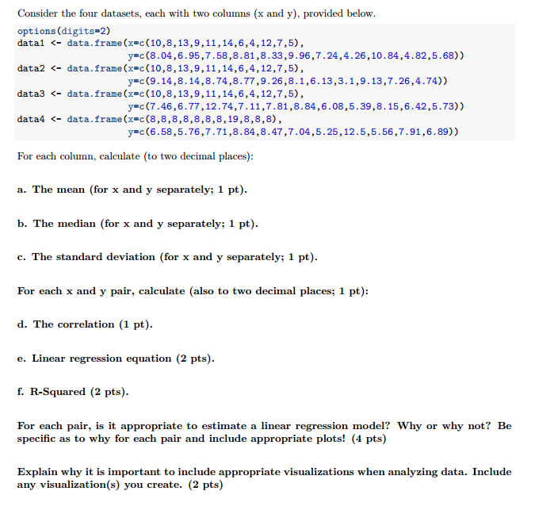

```r
options(digits=2)
data1 <- data.frame(x=c(10,8,13,9,11,14,6,4,12,7,5),
y=c(8.04,6.95,7.58,8.81,8.33,9.96,7.24,4.26,10.84,4.82,5.68))
data2 <- data.frame(x=c(10,8,13,9,11,14,6,4,12,7,5),
y=c(9.14,8.14,8.74,8.77,9.26,8.1,6.13,3.1,9.13,7.26,4.74))
data3 <- data.frame(x=c(10,8,13,9,11,14,6,4,12,7,5),
y=c(7.46,6.77,12.74,7.11,7.81,8.84,6.08,5.39,8.15,6.42,5.73))
data4 <- data.frame(x=c(8,8,8,8,8,8,8,19,8,8,8),
y=c(6.58,5.76,7.71,8.84,8.47,7.04,5.25,12.5,5.56,7.91,6.89))
```

```r
mean(data1$x)
```

```
## [1] 9
```

```r
mean(data1$y)
```

```
## [1] 7.5
```

```r
mean(data2$x)
```

```
## [1] 9
```

```r
mean(data2$y)
```

```
## [1] 7.5
```

```r
mean(data3$x)
```

```
## [1] 9
```

```r
mean(data3$y)
```

```
## [1] 7.5
```

```r
mean(data4$x)
```

```
## [1] 9
```

```r
mean(data4$y)
```

```
## [1] 7.5
```

```r
median(data1$x)
```

```
## [1] 9
```

```r
median(data1$y)
```

```
## [1] 7.6
```

```r
median(data2$x)
```

```
## [1] 9
```

```r
median(data2$y)
```

```
## [1] 8.1
```

```r
median(data3$x)
```

```
## [1] 9
```

```r
median(data3$y)
```

```
## [1] 7.1
```

```r
median(data4$x)
```

```
## [1] 8
```

```r
median(data4$y)
```

```
## [1] 7
```

```r
sd(data1$x)
```

```
## [1] 3.3
```

```r
sd(data1$y)
```

```
## [1] 2
```

```r
sd(data2$x)
```

```
## [1] 3.3
```

```r
sd(data2$y)
```

```
## [1] 2
```

```r
sd(data3$x)
```

```
## [1] 3.3
```

```r
sd(data3$y)
```

```
## [1] 2
```

```r
sd(data4$x)
```

```
## [1] 3.3
```

```r
sd(data4$y)
```

```
## [1] 2
```

```r
cor(data1)
```

```
##      x    y
## x 1.00 0.82
## y 0.82 1.00
```

```r
cor(data2)
```

```
##      x    y
## x 1.00 0.82
## y 0.82 1.00
```

```r
cor(data3)
```

```
##      x    y
## x 1.00 0.82
## y 0.82 1.00
```

```r
data1.lm <- lm(y~x, data=data1)
data2.lm <- lm(y~x, data=data2)
data3.lm <- lm(y~x, data=data3)

summary(data1.lm)
```

```
##
## Call:
## lm(formula = y ~ x, data = data1)
##
## Residuals:
##     Min      1Q  Median      3Q     Max
## -1.9213 -0.4558 -0.0414  0.7094  1.8388
##
## Coefficients:
##             Estimate Std. Error t value Pr(>|t|)
## (Intercept)    3.000      1.125    2.67   0.0257 *
## x              0.500      0.118    4.24   0.0022 **
## ---
## Signif. codes:  0 '***' 0.001 '**' 0.01 '*' 0.05 '.' 0.1 ' ' 1
##
## Residual standard error: 1.2 on 9 degrees of freedom
## Multiple R-squared:  0.667,  Adjusted R-squared:  0.629
## F-statistic:   18 on 1 and 9 DF,  p-value: 0.00217
```

```r
summary(data2.lm)
```

```
##
## Call:
## lm(formula = y ~ x, data = data2)
##
## Residuals:
##    Min     1Q Median     3Q    Max
## -1.901 -0.761  0.129  0.949  1.269
##
## Coefficients:
##             Estimate Std. Error t value Pr(>|t|)
## (Intercept)    3.001      1.125    2.67   0.0258 *
## x              0.500      0.118    4.24   0.0022 **
## ---
## Signif. codes:  0 '***' 0.001 '**' 0.01 '*' 0.05 '.' 0.1 ' ' 1
##
## Residual standard error: 1.2 on 9 degrees of freedom
## Multiple R-squared:  0.666,  Adjusted R-squared:  0.629
## F-statistic:   18 on 1 and 9 DF,  p-value: 0.00218
```

```r
summary(data3.lm)
```

```
##
## Call:
## lm(formula = y ~ x, data = data3)
##
## Residuals:
##    Min     1Q Median     3Q    Max
## -1.159 -0.615 -0.230  0.154  3.241
##
## Coefficients:
##             Estimate Std. Error t value Pr(>|t|)
## (Intercept)    3.002      1.124    2.67   0.0256 *
## x              0.500      0.118    4.24   0.0022 **
## ---
## Signif. codes:  0 '***' 0.001 '**' 0.01 '*' 0.05 '.' 0.1 ' ' 1
##
## Residual standard error: 1.2 on 9 degrees of freedom
## Multiple R-squared:  0.666,  Adjusted R-squared:  0.629
## F-statistic:   18 on 1 and 9 DF,  p-value: 0.00218
```

**Data1 Regression equation is:**

$$\hat{y} = 3.0 + 0.5 * x$$

The R-squared = 0.667

**Data2 Regresstion equation is:**

$$\hat{y} = 3.001 + 0.5 * x$$
The R-squrared = 0.666

**Data3 Regression equation is:**
$$\hat{y} = 3.002 + 0.5 * x$$

The R-squared = 0.666

Appropriateness of linear model estimation:

Condition 1: Linearity Condition 2: Constant variability Condition 3: Nearly normal residuals

Data1 plots:

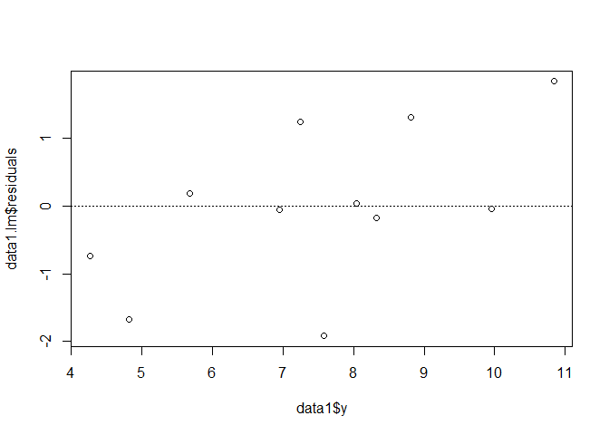

```r
plot(data1.lm$residuals ~ data1$y)
abline(h=0, lty=3)
```

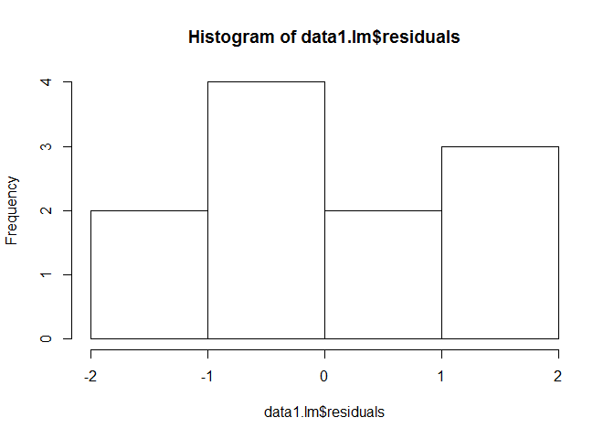

```r
hist(data1.lm$residuals)
```

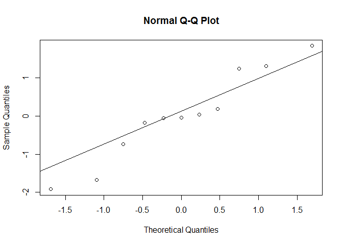

```r
qqnorm(data1.lm$residuals)
qqline(data1.lm$residuals)
```

Data2 plots:

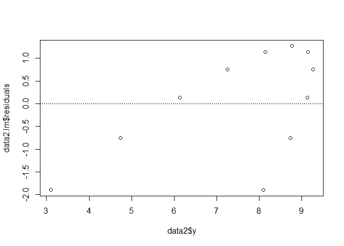

```r
plot(data2.lm$residuals ~ data2$y)
abline(h=0, lty=3)
```

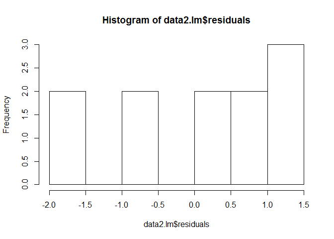

```r
hist(data2.lm$residuals)
```

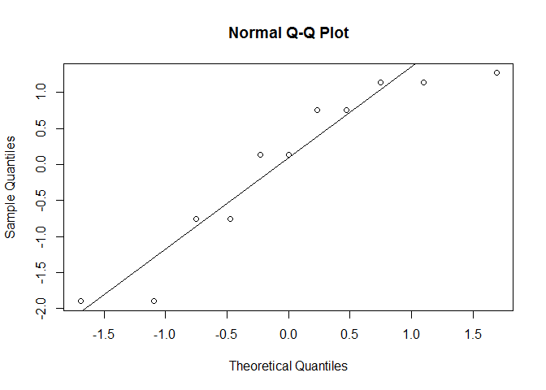

```r
qqnorm(data2.lm$residuals)
qqline(data2.lm$residuals)
```

Data 2 does not satisfy conditions

Data 3 plots:

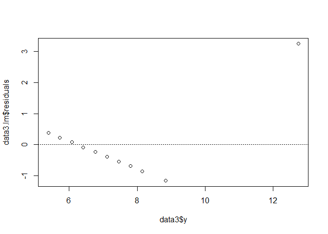

```r
plot(data3.lm$residuals ~ data3$y)
abline(h=0, lty=3)
```

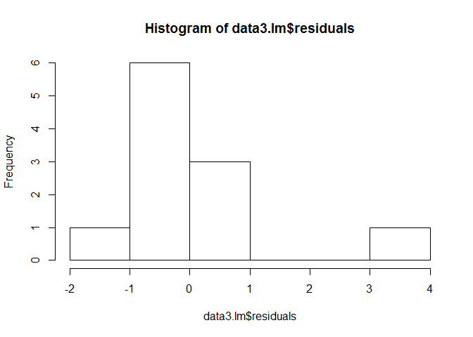

```r
hist(data3.lm$residuals)
```

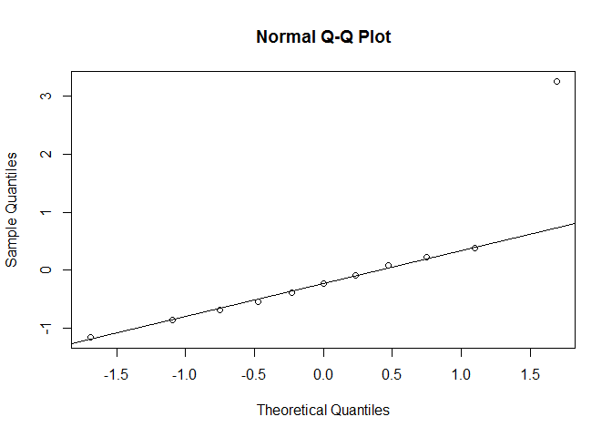

```r
qqnorm(data3.lm$residuals)
qqline(data3.lm$residuals)
```

**Plots are important as they allow us to see a clearer picture that we may not otherwise see from figures alone.**